# Data visualization - independent exercises

#### **1. Getting the data**

**1.1** Just like we did yesterday, install the package `rjstat` (`install.packages("rjstat")`) if you do not have it already installed. Then load the necessary libraries by copy-pasting the following lines into an R script and running them in RStudio.

```r
library(rjstat)
library(tidyverse)
```

**1.2** Retrieve the coronavirus observations data from the THL website. We will use the same data that we worked with yesterday.

Getting the data was covered in the Day 1 extra exercises, so you can run through the following code chunk in your Rstudio session. You can highlight the code below and copy-paste it into a new R script.

```r
# Getting the data
url <- "https://sampo.thl.fi/pivot/prod/en/epirapo/covid19case/fact_epirapo_covid19case.json?"

measure.infections <- "measure-444833"
time.day <- "dateweek2020010120201231-443702L"
region.shp <- "hcdmunicipality2020-445222"

# Combine the URL to a character string
url.call <- paste0(url, "column=", measure.infections, "&row=", time.day, "&row=",
    region.shp)

# Read the data in to an R object and select the object `COVID-19 cases in the
# infectious diseases registry` Note how this step differs a little from what we
# did yesterday

data <- fromJSONstat(readLines(url.call, encoding = "UTF-8"))$`COVID-19 cases in the infectious diseases registry`

# Convert the value column to numeric
data$value <- as.numeric(data$value)
```

#### **2. Data wrangling**

First, we will do some data wrangling to format the data for `ggplot2`. Go through each step carefully to form an understanding of what is happening as you are running through the code. Make sure to copy and run each line!

**2.1** Let’s make a copy of the data and format them so that they are suitable for plotting with `ggplot2`.

```r
plotdata <- data
```

**2.2** Filter out NA values.

```r
plotdata <- plotdata %>% filter(!is.na(value))
```

**2.3** Convert the column containing hospital districts (`hcdmunicipality2020`) into a factor.

```r
plotdata$region <- as.factor(plotdata$hcdmunicipality2020)
```

**2.4** Convert the date values from character format to actual dates (this is very useful for plotting).

```r
plotdata$week <- as.Date(plotdata$dateweek2020010120201231)
```

**2.5** Check the structure of the data. The output should look like the example below.

```r
str(plotdata)
```

```
'data.frame':   1826 obs. of  6 variables:
 $ dateweek2020010120201231: chr  "2020-01-29" "2020-01-29" "2020-01-29" "2020-01-29" ...
 $ hcdmunicipality2020     : chr  "Åland" "Varsinais-Suomi Hospital District" "Satakunta Hospital District" "Kanta-Häme Hospital District" ...
 $ measure                 : chr  "Number of cases" "Number of cases" "Number of cases" "Number of cases" ...
 $ value                   : num  0 0 0 0 0 0 0 0 0 0 ...
 $ region                  : Factor w/ 22 levels "Åland","All areas",..: 1 22 18 9 16 15 10 19 5 7 ...
 $ week                    : Date, format: "2020-01-29" "2020-01-29" ...
```

**2.6** Group the data by region to create regional sums (similar to yesterday’s excercise).

```r
plotdata_sums <- plotdata %>%
  group_by(region) %>%
  summarise(observations = sum(value, na.rm = TRUE))
```

Ok! Now we’re ready to create some plots.

#### **3. Exercises**

**3.1** Plot the regional sums of COVID-19 observations using `plotdata_sums`. Hint: use `geom_col()`.

```r
# Write the answer in your R script

ggplot(data = plotdata_sums,
       aes(x = region, y = observations)) +
  geom_col() +
  theme(axis.text.x = element_text(angle = 90, hjust = 1))
```

**3.2** Now let’s create a plot using the original `plotdata` data frame (which has the daily values). This plot does not look very good…

```r
ggplot(data = plotdata,
       aes(x = week, y = value))+
  geom_line()
```

**3.3** Try improving the previous plot by separating each region. Hint: Add a parameter to `geom_line()`.

```r
# Write the answer in your R script

ggplot(data = plotdata,
       aes(x = week, y = value))+
  geom_line(size = 1, aes(color = region))
```

**3.4** Next, let’s plot regional cumulative sums of COVID-19 observations. Add a new column that has the daily cumulative sum for each region. Note that we use `cumsum()` to calculate this.

```r
plotdata <- plotdata %>% group_by(region) %>% mutate(cumulative_sum = cumsum(value))
```

**3.5** Plot the cumulative sum. You can try different geoms here.

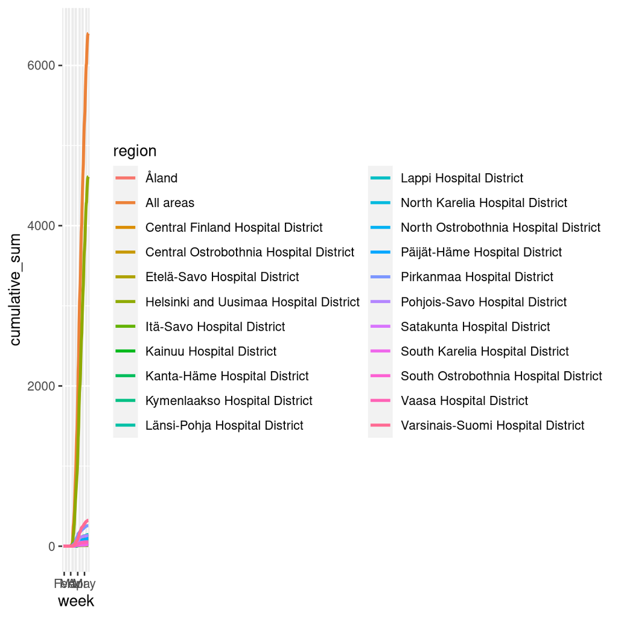

```r
# Write the answer(s) in your R script

# Using geom_line()
ggplot(data = plotdata, aes(x = week, y = cumulative_sum)) + geom_line(size = 1,
    aes(color = region))
```

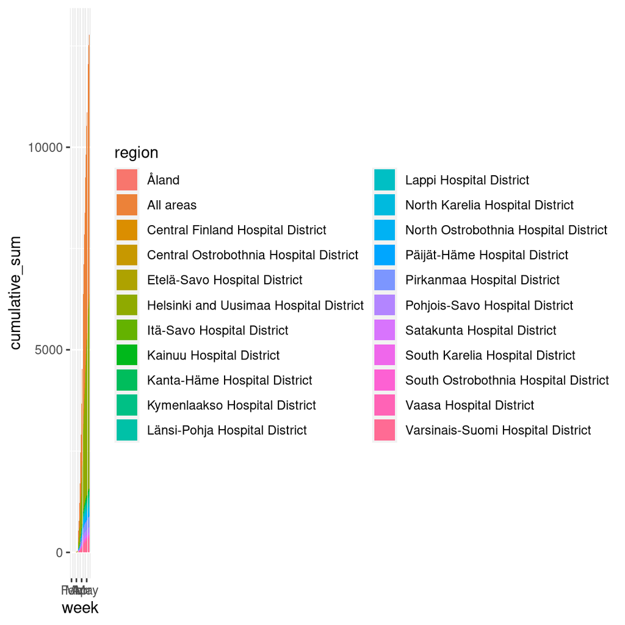

```r
# Using geom_col()
ggplot(data = plotdata, aes(x = week, y = cumulative_sum)) + geom_col(size = 1, aes(fill = region))
```

**3.6** Play around with the plot.

You can, for example, change the y-axis to log scale and select specific regions to plot.

If you are feeling brave, get some more data from the THL website and get creative!

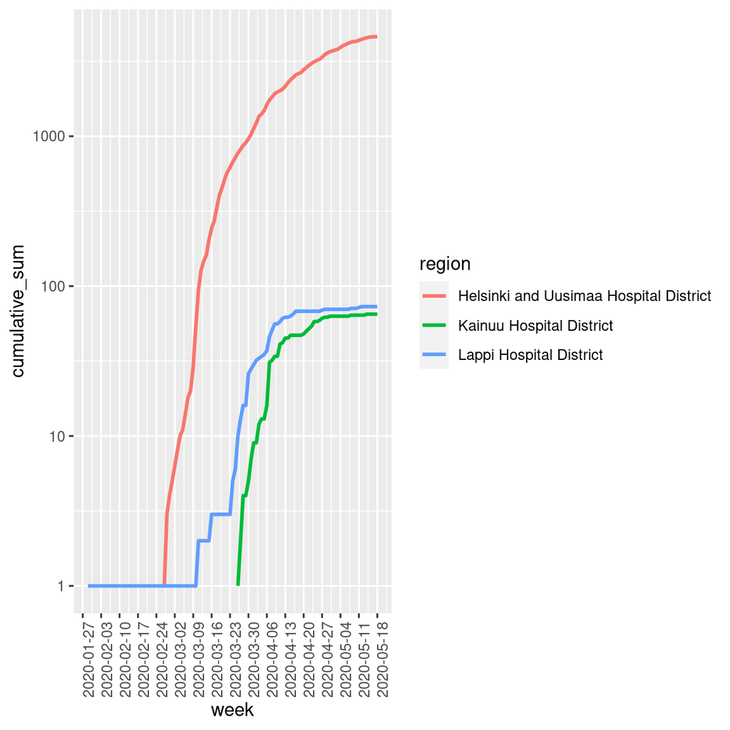

```r
# Continue the code below ...

# ggplot(data = ..., aes()) +

ggplot(data = plotdata %>% filter(region %in% c("Lappi Hospital District", "Kainuu Hospital District",
    "Helsinki and Uusimaa Hospital District") & cumulative_sum > 0), aes(x = week,
    y = cumulative_sum)) + geom_line(size = 1, aes(color = region)) + scale_y_log10() +
    scale_x_date(date_breaks = "1 week") + theme(axis.text.x = element_text(angle = 90,
    hjust = 1))
```

#### **3. Saving and exporting your script**

If you don’t remember how to save and export your data from RStudio Server, follow the instructions set out in the [Starting with data exercise sheet](https://e-learn.csc.fi/mod/resource/view.php?id=574) (steps 7.3 and 7.4).

That’s it in terms of exercises! As this is the last part of the course, we will not go through the solutions in a Zoom session. However, if you’re unsure about how to solve some of the problems above, you can have a look at the completed exercise sheets on eLena.

Thanks for joining the course and we hope you’ve found the contents useful!